[figure not shown]

[figure not shown]

# Mass Killings in America

```python
import pandas as pd, numpy as np, seaborn as sns, matplotlib.pyplot as plt, matplotlib as mlt, geopandas as gp, geodatasets
mlt.rcParams['axes.facecolor'] = "lightgray"
```

```python
mk_incident_public = "https://query.data.world/s/f5axjxaynrhsg2qkkpgxjzoqbdvkat?dws=00000"
mkip_data = pd.read_table(mk_incident_public, delimiter=",", header=0, skipinitialspace=True, engine="python", encoding="utf-8", encoding_errors="strict", on_bad_lines="warn")
mkip_data.rename(str.title, axis="columns", inplace=True)
mkip_data.rename({"Incident_Id":"Incident_ID","Firstcod":"FirstCOD", "Secondcod":"SecondCOD" }, axis="columns", inplace=True)
mkip_data['FirstCOD'] = [s.title() for s in mkip_data['FirstCOD']]
mkip_data['Location_Type'] = [s.title() for s in mkip_data['Location_Type']]
```

```python
mkip_data.head(3)
```

|  | Incident_ID | Date | City | State | Num_Offenders | Num_Victims_Killed | Num_Victims_Injured | FirstCOD | SecondCOD | Type | Situation_Type | Location_Type | Location | Longitude | Latitude | Narrative |
| --- | --- | --- | --- | --- | --- | --- | --- | --- | --- | --- | --- | --- | --- | --- | --- | --- |
| 0 | 577 | 2023-06-18 | Kellogg | ID | 1 | 4 | 0 | Shooting | NaN | Other | Interpersonal conflict | Residence/Other Shelter | Residence | -116.12796 | 47.544170 | A 31-year-old man has been arrested in connect... |
| 1 | 578 | 2023-06-15 | Sequatchie | TN | 1 | 5 | 1 | Shooting | Smoke inhalation & burns | Family | Family issue | Residence/Other Shelter | Residence | -85.60012 | 35.115750 | Gary Don Barnett killed his estranged wife, he... |
| 2 | 576 | 2023-05-27 | Mesa | AZ | 1 | 4 | 1 | Shooting | NaN | Public | NaN | Multiple | Multiple | -111.82608 | 33.415184 | Iren Byers, 20, is charged with killing four p... |

## Exploratory Data Analysis

```python
mkip_data.tail(3)
```

|  | Incident_ID | Date | City | State | Num_Offenders | Num_Victims_Killed | Num_Victims_Injured | FirstCOD | SecondCOD | Type | Situation_Type | Location_Type | Location | Longitude | Latitude | Narrative |
| --- | --- | --- | --- | --- | --- | --- | --- | --- | --- | --- | --- | --- | --- | --- | --- | --- |
| 556 | 97 | 2006-02-21 | Mesa | AZ | 1 | 5 | 0 | Shooting | NaN | Felony | Other | Residence/Other Shelter | Residence | -111.822640 | 33.422269 | William Miller, 28, of Scottsdale, AZ killed t... |
| 557 | 109 | 2006-01-30 | Goleta | CA | 1 | 7 | 0 | Shooting | NaN | Public | Employment grievance | Government/Transit | Government/Transit | -119.827639 | 34.435829 | Three years after disability retirement for ps... |
| 558 | 98 | 2006-01-01 | Richmond | VA | 2 | 7 | 0 | Stabbing | Strangulation | Felony | Robbery | Residence/Other Shelter | Residence | -77.460262 | 37.553758 | Ricky Gray, 28, was convicted of murdering a f... |

```python
mkip_data.index
```

```
RangeIndex(start=0, stop=559, step=1)
```

```python
mkip_data.shape
```

```
(559, 16)
```

```python
mkip_data.size
```

```
8944
```

```python
mkip_data.ndim
```

```
2
```

```python
mkip_data.dtypes
```

```
Incident_ID              int64
Date                    object
City                    object
State                   object
Num_Offenders            int64
Num_Victims_Killed       int64
Num_Victims_Injured      int64
FirstCOD                object
SecondCOD               object
Type                    object
Situation_Type          object
Location_Type           object
Location                object
Longitude              float64
Latitude               float64
Narrative               object
dtype: object
```

```python
mkip_data.columns
```

```
Index(['Incident_ID', 'Date', 'City', 'State', 'Num_Offenders',
       'Num_Victims_Killed', 'Num_Victims_Injured', 'FirstCOD', 'SecondCOD',
       'Type', 'Situation_Type', 'Location_Type', 'Location', 'Longitude',
       'Latitude', 'Narrative'],
      dtype='object')
```

```python
for ele in ['FirstCOD', 'SecondCOD','Type', 'Situation_Type', 'Location_Type', 'Location']:
    print(mkip_data[ele].unique())
```

```
['Shooting' 'Smoke Inhalation & Burns' 'Stabbing' 'Vehicle Crash'
 'Asphyxiation' 'Blunt Force' 'Unknown' 'Drowning' 'Strangulation'
 'Pushing/Jumping']
[nan 'Smoke inhalation & burns' 'Stabbing' 'Asphyxiation' 'Vehicle crash'
 'Other' 'Strangulation' 'Blunt force' 'Drowning']
['Other' 'Family' 'Public' 'Suspected felony' 'Felony' 'Undetermined'
 'Unsolved']
['Interpersonal conflict' 'Family issue' nan 'Other' 'Indiscriminate'
 'Employment grievance' 'Arson' 'Drug trade' 'Despondency' 'Hate'
 'Robbery' 'Profit' 'Undetermined' 'Gang conflict' 'Terrorism']
['Residence/Other Shelter' 'Multiple' 'Commercial/Retail/Entertainment'
 'School/College' 'Open Space' 'Vehicle' 'Medical Facility'
 'House Of Worship' 'Government/Transit']
['Residence' 'Multiple' 'Commercial/Retail' 'Bar/Club/Restaurant' 'School'
 'Open space' 'Vehicle' 'Medical facility' 'Hotel/Motel'
 'House of worship' 'Government/Transit' 'Shelter/Drug house' 'College']
```

```python
mkip_data.info()
```

```
<class 'pandas.core.frame.DataFrame'>
RangeIndex: 559 entries, 0 to 558
Data columns (total 16 columns):
 #   Column               Non-Null Count  Dtype
---  ------               --------------  -----
 0   Incident_ID          559 non-null    int64
 1   Date                 559 non-null    object
 2   City                 559 non-null    object
 3   State                559 non-null    object
 4   Num_Offenders        559 non-null    int64
 5   Num_Victims_Killed   559 non-null    int64
 6   Num_Victims_Injured  559 non-null    int64
 7   FirstCOD             559 non-null    object
 8   SecondCOD            78 non-null     object
 9   Type                 559 non-null    object
 10  Situation_Type       536 non-null    object
 11  Location_Type        559 non-null    object
 12  Location             559 non-null    object
 13  Longitude            559 non-null    float64
 14  Latitude             559 non-null    float64
 15  Narrative            559 non-null    object
dtypes: float64(2), int64(4), object(10)
memory usage: 70.0+ KB
```

```python
cat = mkip_data['FirstCOD'].unique()
c = mkip_data.groupby(mkip_data['FirstCOD']).FirstCOD.count()
duplicates = set()
# print(sum(1 for item in cat if all(item in mkip_data['FirstCod'])))
sum(1 for cat in mkip_data['FirstCOD'])
```

```
559
```

```python
mkip_data.select_dtypes(include="object").nunique()
```

```
Date              533
City              429
State              48
FirstCOD           10
SecondCOD           8
Type                7
Situation_Type     14
Location_Type       9
Location           13
Narrative         559
dtype: int64
```

```python
if not(any(mkip_data.notna())) or not(any(mkip_data.notnull())):
    print("All Good")
else:
    print("Work to be Done")
```

```
Work to be Done
```

```python
100 * mkip_data.isnull().sum() / mkip_data.shape[0]
```

```
Incident_ID             0.000000
Date                    0.000000
City                    0.000000
State                   0.000000
Num_Offenders           0.000000
Num_Victims_Killed      0.000000
Num_Victims_Injured     0.000000
FirstCOD                0.000000
SecondCOD              86.046512
Type                    0.000000
Situation_Type          4.114490
Location_Type           0.000000
Location                0.000000
Longitude               0.000000
Latitude                0.000000
Narrative               0.000000
dtype: float64
```

## Data Analysis and Visualization

```python
mkip_data[["Num_Offenders","Num_Victims_Killed","Num_Victims_Injured"]].describe().round()
```

|  | Num_Offenders | Num_Victims_Killed | Num_Victims_Injured |
| --- | --- | --- | --- |
| count | 559.0 | 559.0 | 559.0 |
| mean | 1.0 | 5.0 | 4.0 |
| std | 1.0 | 4.0 | 37.0 |
| min | 0.0 | 4.0 | 0.0 |
| 25% | 1.0 | 4.0 | 0.0 |
| 50% | 1.0 | 4.0 | 0.0 |
| 75% | 1.0 | 5.0 | 1.0 |
| max | 7.0 | 60.0 | 867.0 |

```python
print("Total Number of Mass Violence Incidents: ",  mkip_data.Incident_ID.sum())
print("Total Number of Victims: ",  mkip_data.Num_Victims_Killed.sum())
print("Total Number of Victims: ",  mkip_data.Num_Victims_Injured.sum())
```

[output not shown]

```python
mkip_data.groupby("Date", axis=0).filter(lambda x: (x.nunique() > 1).any()).iloc[:, 1:8]
# mkip_data["Same_Day"] = mkip_data.groupby("Date", axis=0).nunique()
```

|  | Date | City | State | Num_Offenders | Num_Victims_Killed | Num_Victims_Injured | FirstCOD |
| --- | --- | --- | --- | --- | --- | --- | --- |
| 6 | 2023-04-30 | Mojave | CA | 1 | 4 | 0 | Shooting |
| 7 | 2023-04-30 | Henryetta | OK | 1 | 6 | 0 | Shooting |
| 30 | 2022-11-20 | Colorado Springs | CO | 1 | 5 | 17 | Shooting |
| 31 | 2022-11-20 | Hennessey | OK | 1 | 4 | 1 | Shooting |
| 35 | 2022-11-04 | Orlando | FL | 1 | 4 | 1 | Shooting |
| 36 | 2022-11-04 | La Plata | MD | 1 | 4 | 0 | Shooting |
| 40 | 2022-10-17 | Woodbridge | VA | 1 | 4 | 0 | Shooting |
| 41 | 2022-10-17 | South Fulton | GA | 1 | 4 | 5 | Smoke Inhalation & Burns |
| 43 | 2022-10-09 | Inman | SC | 1 | 5 | 0 | Shooting |
| 44 | 2022-10-09 | Henryetta | OK | 1 | 4 | 0 | Shooting |
| 60 | 2022-05-14 | Buffalo | NY | 1 | 10 | 3 | Shooting |
| 61 | 2022-05-14 | Worcester | MA | 1 | 4 | 3 | Smoke Inhalation & Burns |
| 68 | 2022-01-23 | Milwaukee | WI | 1 | 6 | 0 | Shooting |
| 69 | 2022-01-23 | Inglewood | CA | 1 | 4 | 1 | Shooting |
| 81 | 2021-09-05 | Lakeland | FL | 1 | 4 | 2 | Shooting |
| 82 | 2021-09-05 | Houston | TX | 1 | 4 | 0 | Shooting |
| 119 | 2020-06-04 | San Antonio | TX | 1 | 5 | 0 | Asphyxiation |
| 120 | 2020-06-04 | Valhermoso Springs | AL | 2 | 7 | 0 | Shooting |
| 123 | 2020-03-15 | Moncure | NC | 1 | 6 | 0 | Shooting |
| 124 | 2020-03-15 | Springfield | MO | 1 | 4 | 2 | Shooting |
| 153 | 2019-07-06 | Port Angeles | WA | 1 | 4 | 0 | Smoke Inhalation & Burns |
| 154 | 2019-07-06 | North St. Louis County | MO | 2 | 5 | 0 | Shooting |
| 199 | 2018-01-28 | Melcroft | PA | 1 | 4 | 1 | Shooting |
| 200 | 2018-01-28 | Reading | PA | 4 | 4 | 0 | Shooting |
| 222 | 2017-04-07 | Houston | TX | 1 | 4 | 0 | Shooting |
| 223 | 2017-04-07 | Columbia | SC | 2 | 4 | 0 | Blunt Force |
| 225 | 2017-03-22 | Rothschild | WI | 1 | 4 | 0 | Shooting |
| 226 | 2017-03-22 | Sacramento | CA | 1 | 4 | 0 | Blunt Force |
| 256 | 2016-04-22 | Appling | GA | 1 | 5 | 0 | Shooting |
| 257 | 2016-04-22 | Piketon | OH | 4 | 8 | 0 | Shooting |
| 280 | 2015-07-22 | Broken Arrow | OK | 2 | 5 | 1 | Stabbing |
| 281 | 2015-07-22 | Suwanee | GA | 1 | 4 | 0 | Shooting |
| 282 | 2015-07-18 | Modesto | CA | 1 | 5 | 0 | Stabbing |
| 283 | 2015-07-18 | Chicago | IL | 1 | 4 | 0 | Smoke Inhalation & Burns |
| 320 | 2014-02-20 | Alturas | CA | 1 | 4 | 2 | Shooting |
| 321 | 2014-02-20 | Indianapolis | IN | 4 | 4 | 0 | Shooting |
| 325 | 2013-11-23 | Parsons | KS | 1 | 4 | 0 | Strangulation |
| 326 | 2013-11-23 | Tulsa | OK | 1 | 4 | 1 | Shooting |
| 338 | 2013-07-26 | Clarksburg | WV | 1 | 4 | 0 | Shooting |
| 339 | 2013-07-26 | Hialeah | FL | 1 | 6 | 0 | Shooting |
| 388 | 2011-07-07 | Wheatland | WY | 1 | 4 | 1 | Shooting |
| 389 | 2011-07-07 | Grand Rapids | MI | 1 | 7 | 2 | Shooting |
| 397 | 2011-02-11 | Brooklyn | NY | 1 | 4 | 5 | Stabbing |
| 398 | 2011-02-11 | Willowbrook | CA | 1 | 4 | 0 | Shooting |
| 446 | 2009-03-29 | Carthage | NC | 1 | 8 | 2 | Shooting |
| 447 | 2009-03-29 | Santa Clara | CA | 1 | 5 | 1 | Shooting |
| 487 | 2008-02-07 | Kirkwood | MO | 1 | 6 | 1 | Shooting |
| 488 | 2008-02-07 | Los Angeles | CA | 1 | 4 | 1 | Shooting |
| 489 | 2008-02-02 | Tinley Park | IL | 1 | 5 | 1 | Shooting |
| 490 | 2008-02-02 | Cockeysville | MD | 1 | 4 | 0 | Shooting |
| 529 | 2006-10-14 | Kansas City | KS | 2 | 4 | 0 | Shooting |
| 530 | 2006-10-14 | Bonaparte | IA | 1 | 5 | 0 | Shooting |

### Mass Violence by State

```python
state_count = mkip_data.groupby(["State"]).Incident_ID.count().sort_values(ascending=False)
state_num_victims = mkip_data.groupby(["State"]).Num_Victims_Killed.sum().sort_values(ascending=False)
print(state_num_victims)
```

```
State
CA    320
TX    301
FL    196
IL    149
OH    123
VA    110
NY    107
GA     85
AZ     83
NV     80
PA     76
WA     75
MI     70
AL     69
TN     68
NC     68
SC     67
IN     65
MO     63
OK     61
WI     61
LA     60
CO     56
CT     40
MS     38
MD     38
OR     35
KS     35
KY     31
NJ     28
MA     28
WV     26
DC     24
UT     20
NM     19
MN     18
AR     17
NE     16
ID     12
ND     12
IA     10
AK      8
ME      8
DE      8
WY      8
SD      5
VT      4
MT      4
Name: Num_Victims_Killed, dtype: int64
```

[figure not shown]

```python
from PIL import Image
plt.figure(figsize=(8,4), constrained_layout=True, dpi=120)
plt.imshow(np.asarray(Image.open('images.png')))
```

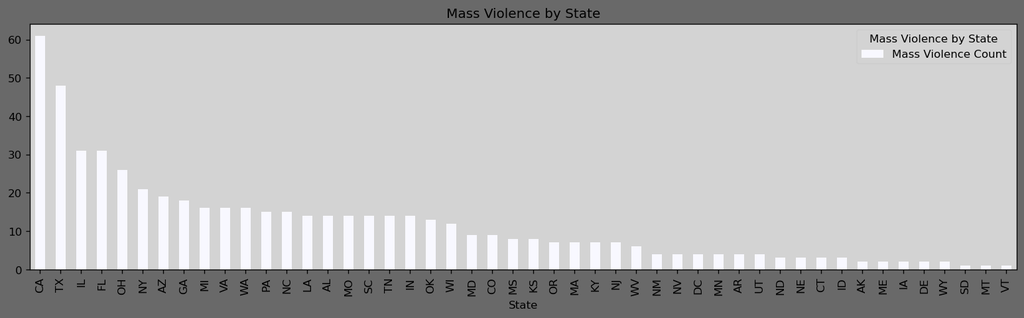

```python
fig, axe = plt.subplots(figsize=(16,4), constrained_layout=False, dpi=120, facecolor="dimgray", label="Mass Violence by State")
state_count.plot.bar(color="ghostwhite")
axe.legend(labels=["Mass Violence Count"], loc="upper right", mode="none", title="Mass Violence by State")
axe.set_xlabel("State")
axe.set_title("Mass Violence by State")
axe.plot();
```

```python
state_avg_victims = mkip_data.groupby(["State"]).Num_Victims_Killed.mean().sort_values(ascending=False).round()
state_avg_victims
```

```
State
NV    20.0
CT    13.0
VA     7.0
FL     6.0
TX     6.0
CO     6.0
DC     6.0
NE     5.0
CA     5.0
NY     5.0
WI     5.0
PA     5.0
IA     5.0
OR     5.0
UT     5.0
SD     5.0
AL     5.0
TN     5.0
IL     5.0
SC     5.0
NM     5.0
MS     5.0
OH     5.0
GA     5.0
OK     5.0
WA     5.0
IN     5.0
NC     5.0
MN     4.0
MO     4.0
KY     4.0
KS     4.0
MI     4.0
AZ     4.0
WV     4.0
LA     4.0
AR     4.0
MD     4.0
VT     4.0
AK     4.0
NJ     4.0
ND     4.0
MT     4.0
ME     4.0
MA     4.0
ID     4.0
DE     4.0
WY     4.0
Name: Num_Victims_Killed, dtype: float64
```

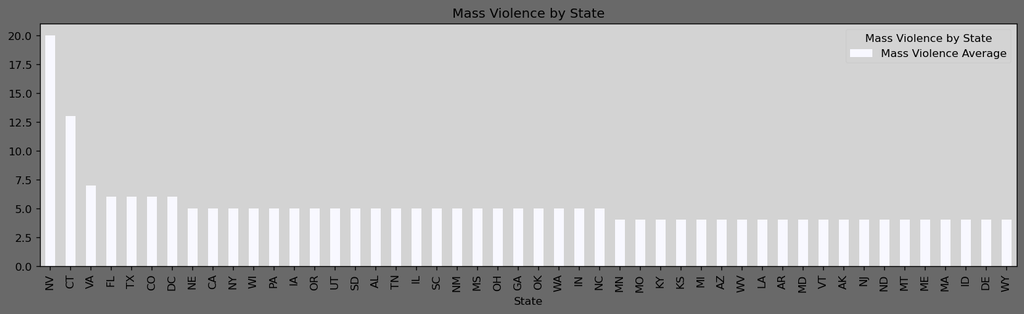

```python
fig, axe = plt.subplots(figsize=(16,4), constrained_layout=False, dpi=120, facecolor="dimgray", label="Mass Violence by State")
# state_avg_victims.plot.line(color="black")
state_avg_victims.plot.bar(color="ghostwhite")
axe.legend(labels=["Mass Violence Average"], loc="upper right", mode="none", title="Mass Violence by State")
axe.set_xlabel("State")
axe.set_title("Mass Violence by State")
axe.plot();
```

### Mass Violence by Year

```python
mkip_data["Date_Year"] = pd.to_datetime(mkip_data["Date"], errors="coerce", yearfirst=True).dt.year
date_count = mkip_data.groupby(["Date_Year"]).Incident_ID.count()
print(date_count)
```

```
Date_Year
2006    38
2007    26
2008    36
2009    32
2010    26
2011    30
2012    22
2013    25
2014    25
2015    31
2016    34
2017    33
2018    25
2019    46
2020    25
2021    35
2022    42
2023    28
Name: Incident_ID, dtype: int64
```

[figure not shown]

```python
fig, axe = plt.subplots(figsize=(16,4), constrained_layout=False, dpi=120, facecolor="dimgray", label="Mass Violence by Year")
date_count.plot.bar(color="ghostwhite")
axe.legend(labels=["Mass Violence Count"], loc="upper right", mode="none", title="Mass Violence by Year")
axe.set_xlabel("Year")
axe.set_title("Mass Violence by Year")
axe.plot();
```

```python
mkip_data["Date_Year"] = pd.to_datetime(mkip_data["Date"], errors="coerce", yearfirst=True).dt.year
date_mean = mkip_data.groupby(["Date_Year"]).Incident_ID.mean().round(1)
print(date_mean)
```

```
Date_Year
2006    113.3
2007    112.9
2008     96.0
2009     73.4
2010     66.8
2011    159.9
2012    149.8
2013    206.2
2014    253.0
2015    282.0
2016    328.9
2017    339.5
2018    362.0
2019    405.8
2020    444.4
2021    476.1
2022    522.0
2023    561.3
Name: Incident_ID, dtype: float64
```

[figure not shown]

```python
fig, axe = plt.subplots(figsize=(16,4), constrained_layout=False, dpi=120, facecolor="dimgray", label="Mass Violence by Year")
date_mean.plot.bar(color="ghostwhite")
axe.legend(labels=["Mass Violence Average"], loc="upper right", mode="none", title="Mass Violence by Year")
axe.set_xlabel("Year")
axe.set_title("Mass Violence by Year")
axe.plot();
```

```python
roc_mean = date_mean.pct_change()
```

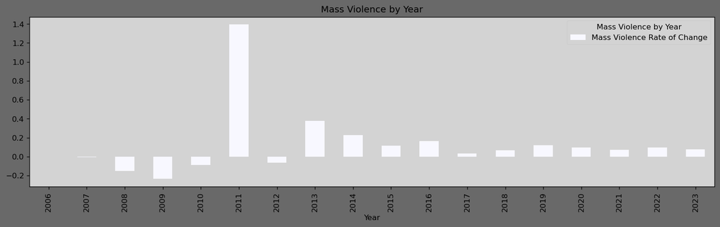

```python
fig, axe = plt.subplots(figsize=(16,4), constrained_layout=False, dpi=120, facecolor="dimgray", label="Mass Violence by Year")
roc_mean.plot.bar(color="ghostwhite")
axe.legend(labels=["Mass Violence Rate of Change"], loc="upper right", mode="none", title="Mass Violence by Year")
axe.set_xlabel("Year")
axe.set_title("Mass Violence by Year")
axe.plot();
```

```python
from bokeh.plotting import figure
from bokeh.io import output_notebook, show
output_notebook()

fig = figure(width=1500, height=500,  title="Mass Violence by Year")
fig.grid.grid_line_alpha=0.3
fig.xaxis.axis_label="Year"
fig.background_fill_color = "lightgray"
fig.vbar(x=date_count.index, top=date_count.values, color="black", width=0.7)

show(fig)
```

[interactive chart not shown]

### Mass Shoots by Type

```python
type_count= mkip_data.groupby(["Type"]).Incident_ID.count().sort_values(ascending=False)
print(type_count)
```

```
Type
Family              267
Public              107
Felony               99
Other                43
Unsolved             21
Suspected felony     18
Undetermined          4
Name: Incident_ID, dtype: int64
```

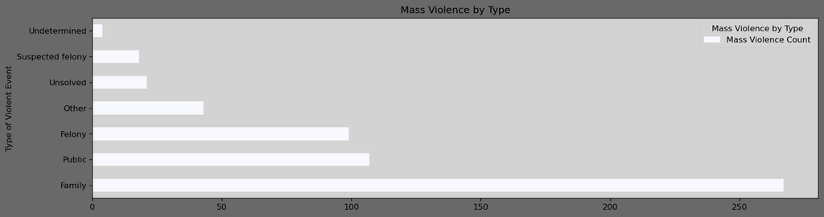

```python
fig, axe = plt.subplots(figsize=(16,4), constrained_layout=False, dpi=120, facecolor="dimgray", label="Mass Violence by Type")
type_count.plot.barh(color="ghostwhite")
axe.legend(labels=["Mass Violence Count"], loc="upper right", mode="none", title="Mass Violence by Type")
axe.set_ylabel("Type of Violent Event")
axe.set_title("Mass Violence by Type")
axe.plot();
```

### Mass Violence by Location

```python
location_count = mkip_data.groupby(["Location"]).Location.count().sort_values(ascending=False)
print(location_count)
```

```
Location
Residence              378
Commercial/Retail       37
Open space              36
Multiple                30
Bar/Club/Restaurant     21
Vehicle                 16
Government/Transit      10
School                   8
House of worship         7
College                  5
Shelter/Drug house       5
Hotel/Motel              3
Medical facility         3
Name: Location, dtype: int64
```

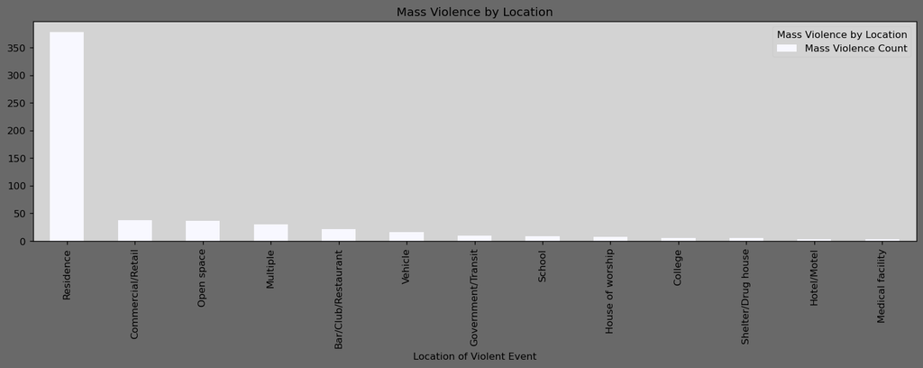

```python
fig, axe = plt.subplots(figsize=(16,4), constrained_layout=False, dpi=120, facecolor="dimgray", label="Mass Violence by Location")
location_count.plot.bar (color="ghostwhite")
axe.legend(labels=["Mass Violence Count"], loc="upper right", mode="none", title="Mass Violence by Location")
axe.set_xlabel("Location of Violent Event")
axe.set_title("Mass Violence by Location")
axe.plot();
```

### Mass Violence by Location Type

```python
print(mkip_data["Location"].unique())
hashLoc = {
"Public" : ['Commercial/Retail', 'Bar/Club/Restaurant', 'School', 'Open space', 'Medical facility', 'Hotel/Motel',
'House of worship','Shelter/Drug house', 'College'],
"Non-Public" : ['Residence'],
"Other" : ['Multiple', 'Vehicle', 'Government/Transit']}
def replace_loc(mkip_data_loc):
    return "".join(key for key, values in hashLoc.items() for value in values if value in mkip_data_loc)

mkip_data["Type_Location"] = mkip_data["Location"].apply(replace_loc)
```

```
['Residence' 'Multiple' 'Commercial/Retail' 'Bar/Club/Restaurant' 'School'
 'Open space' 'Vehicle' 'Medical facility' 'Hotel/Motel'
 'House of worship' 'Government/Transit' 'Shelter/Drug house' 'College']
```

```python
typeLoc_count = mkip_data.groupby(["Type_Location"]).Type_Location.count().sort_values(ascending=False)
print(typeLoc_count)
```

```
Type_Location
Non-Public    378
Public        125
Other          56
Name: Type_Location, dtype: int64
```

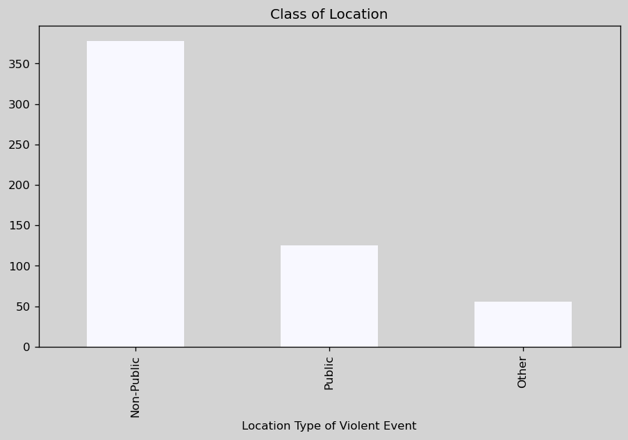

```python
fig, axe = plt.subplots(figsize=(9,5), constrained_layout=False, dpi=120, facecolor="lightgray", label="Mass Violence by Type")
typeLoc_count.plot.bar(stacked=False, color="ghostwhite")
axe.set_xlabel("Location Type of Violent Event")
axe.set_title("Class of Location")
axe.plot();
```

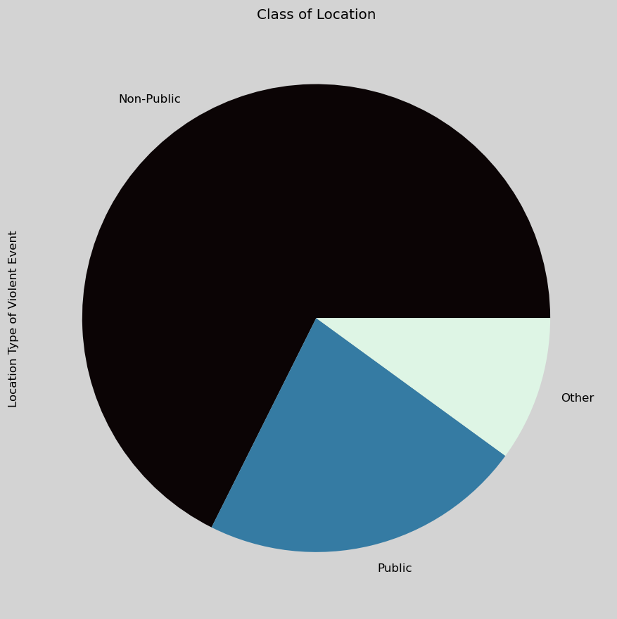

```python
fig, axe = plt.subplots(figsize=(10,9), constrained_layout=False, dpi=120, facecolor="lightgray", label="Mass Violence by Type")
typeLoc_count.plot.pie(stacked=False, cmap="mako")
axe.set_ylabel("Location Type of Violent Event")
axe.set_title("Class of Location")
axe.plot();
```

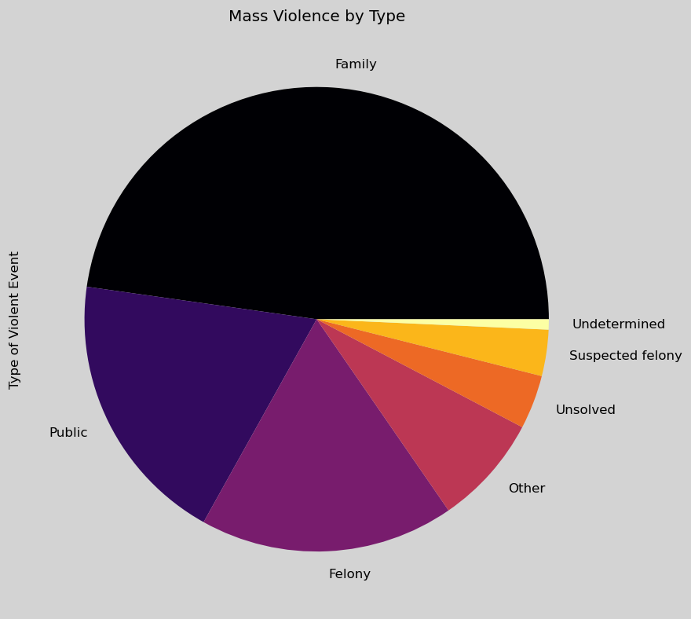

```python
fig, axe = plt.subplots(figsize=(10,8), constrained_layout=False, dpi=120, facecolor="lightgray", label="Mass Violence by Type")
type_count.plot.pie(cmap="inferno")
axe.set_ylabel("Type of Violent Event")
axe.set_title("Mass Violence by Type")
axe.plot();
```

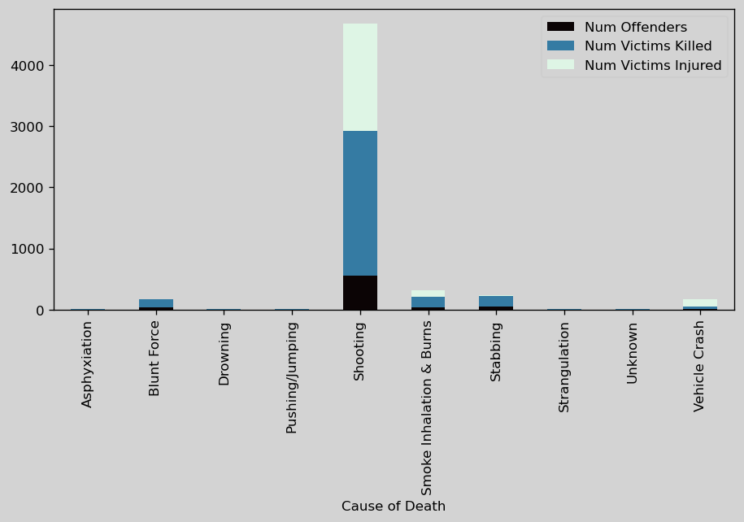

```python
fig, axe = plt.subplots(figsize=(9,4), constrained_layout=False, dpi=120, facecolor="lightgray", label="Mass Violence by Type")
stack = mkip_data.groupby("FirstCOD")["FirstCOD",'Num_Offenders', 'Num_Victims_Killed', 'Num_Victims_Injured'].sum()
stack.rename({"Num_Offenders":"Num Offenders","Num_Victims_Killed":"Num Victims Killed", "Num_Victims_Injured":"Num Victims Injured" }, axis="columns", inplace=True)
stack.plot.bar(ax=axe, stacked=True, cmap="mako")
axe.set_xlabel("Cause of Death")
# axe.set_title("Class of Location")
axe.plot();
```

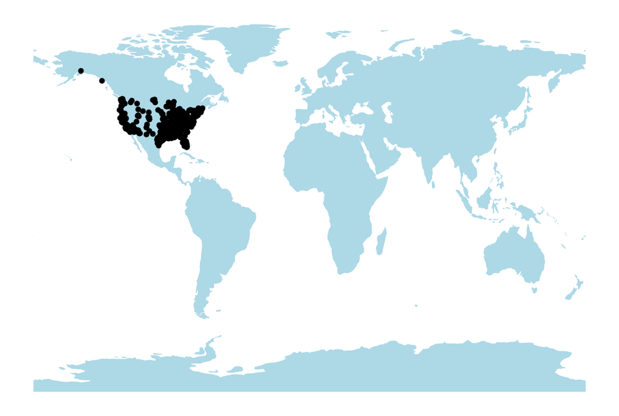

```python
gdf = gp.GeoDataFrame(mkip_data, geometry=gp.points_from_xy(mkip_data.Longitude, mkip_data.Latitude), crs="EPSG:4326")
usa = gp.read_file(geodatasets.get_path('naturalearth.land'))
ax = usa.plot(figsize=(20,9), color="lightblue")
ax.set_axis_off()
gdf.plot(ax=ax, color="black")
```

```python
mk_offenders_public = "https://query.data.world/s/di7bmak4rf6qkkmu2v64xfsei64y2j?dws=00000"
mkop_data = pd.read_table(mk_incident_public, delimiter=",", header=0, skipinitialspace=True, engine="python", encoding="utf-8", encoding_errors="strict", on_bad_lines="warn")
mkop_data.rename(str.title, axis="columns", inplace=True)
mkop_data.rename({"Incident_Id":"Incident_ID","Firstcod":"FirstCOD", "Secondcod":"SecondCOD" }, axis="columns", inplace=True)
mkop_data['FirstCOD'] = [s.title() for s in mkip_data['FirstCOD']]
mkop_data['Location_Type'] = [s.title() for s in mkip_data['Location_Type']]
mkop_data.head(1)
```

|  | Incident_ID | Date | City | State | Num_Offenders | Num_Victims_Killed | Num_Victims_Injured | FirstCOD | SecondCOD | Type | Situation_Type | Location_Type | Location | Longitude | Latitude | Narrative |
| --- | --- | --- | --- | --- | --- | --- | --- | --- | --- | --- | --- | --- | --- | --- | --- | --- |
| 0 | 577 | 2023-06-18 | Kellogg | ID | 1 | 4 | 0 | Shooting | NaN | Other | Interpersonal conflict | Residence/Other Shelter | Residence | -116.12796 | 47.54417 | A 31-year-old man has been arrested in connect... |

```python
mk_victims_public = "https://query.data.world/s/zrk6mdov7k3wkg3sve4e6wylul746d?dws=00000"
mkvp_data = pd.read_table(mk_incident_public, delimiter=",", header=0, skipinitialspace=True, engine="python", encoding="utf-8", encoding_errors="strict", on_bad_lines="warn")
mkvp_data.rename(str.title, axis="columns", inplace=True)
mkvp_data.rename({"Incident_Id":"Incident_ID","Firstcod":"FirstCOD", "Secondcod":"SecondCOD" }, axis="columns", inplace=True)
mkvp_data['FirstCOD'] = [s.title() for s in mkip_data['FirstCOD']]
mkvp_data['Location_Type'] = [s.title() for s in mkip_data['Location_Type']]
mkvp_data.head(1)
```

|  | Incident_ID | Date | City | State | Num_Offenders | Num_Victims_Killed | Num_Victims_Injured | FirstCOD | SecondCOD | Type | Situation_Type | Location_Type | Location | Longitude | Latitude | Narrative |
| --- | --- | --- | --- | --- | --- | --- | --- | --- | --- | --- | --- | --- | --- | --- | --- | --- |
| 0 | 577 | 2023-06-18 | Kellogg | ID | 1 | 4 | 0 | Shooting | NaN | Other | Interpersonal conflict | Residence/Other Shelter | Residence | -116.12796 | 47.54417 | A 31-year-old man has been arrested in connect... |

```python
mk_weapons_public = "https://query.data.world/s/tsuydmpezwzbjormbolhpi6eo34opd?dws=00000"
mkwp_data = pd.read_table(mk_incident_public, delimiter=",", header=0, skipinitialspace=True, engine="python", encoding="utf-8", encoding_errors="strict", on_bad_lines="warn")
mkwp_data.rename(str.title, axis="columns", inplace=True)
mkwp_data.rename({"Incident_Id":"Incident_ID","Firstcod":"FirstCOD", "Secondcod":"SecondCOD" }, axis="columns", inplace=True)
mkwp_data['FirstCOD'] = [s.title() for s in mkip_data['FirstCOD']]
mkwp_data['Location_Type'] = [s.title() for s in mkip_data['Location_Type']]
mkwp_data.head(1)
```

|  | Incident_ID | Date | City | State | Num_Offenders | Num_Victims_Killed | Num_Victims_Injured | FirstCOD | SecondCOD | Type | Situation_Type | Location_Type | Location | Longitude | Latitude | Narrative |
| --- | --- | --- | --- | --- | --- | --- | --- | --- | --- | --- | --- | --- | --- | --- | --- | --- |
| 0 | 577 | 2023-06-18 | Kellogg | ID | 1 | 4 | 0 | Shooting | NaN | Other | Interpersonal conflict | Residence/Other Shelter | Residence | -116.12796 | 47.54417 | A 31-year-old man has been arrested in connect... |

`@Credit: USA TODAY/AP/Northeastern University`

About the data

The USA TODAY/AP/Northeastern University mass killing database contains information on incidents, offenders, victims and weapons for all multiple homicides with four or more victims killed in the United States from 2006 to the present.

Definition

A mass killing is defined as the intentional killing of four or more victims – excluding the deaths of unborn children and the offender(s) – by any means within a 24-hour period.

This definition includes cases involving all weapons (shooting, blunt force, stabbing, explosives), types (public, felony-related, and familicides), motivations (domestic dispute, profit, revenge, terrorism, hate), victim-offender relationships (stranger, family, acquaintance, co-worker), and number of locations. The time frame of 24 hours was chosen to eliminate conflation with spree killers who kill multiple victims over several days in different locations and to satisfy the traditional requirement of occurring in a “single incident,” even if that incident involves an offender targeting multiple locations in an extended assault but within a relatively short time span. However, offenders who kill four or more victims during any 24-hour period of time as part of a multi-day spree are included, as are all their victims within seven days of the mass killing. Negligent homicides related to driving under the influence or accidental fires are excluded because of the lack of intent. Finally, only incidents occurring within the 50 U.S. states and the District of Columbia are included in the database.

Consistent with the traditional definition, fatal mass shootings are mass killings (four or more victim fatalities) in which most or all the victims are killed by gunfire. This differs from an alternative definition used by the Gun Violence Archive that includes incidents in which at least four victims are shot regardless of whether the injury is fatal. Less than 5% of the mass shootings listed in the Gun Violence Archive are defined as mass killings in our database. Our definition of a fatal mass shooting also differs from an active shooter event which, as characterized by the FBI, involves an individual actively engaged in killing or attempting to kill people in a populated area. Less than 25% of active shooter events result in four or more victim fatalities, constituting a mass killing.

Methods

Researchers at USA TODAY first identified potential incidents using the FBI’s Supplementary Homicide Reports (SHR). Homicide incidents in the SHR were flagged as potential mass killing cases if four or more victims were reported on the same record, and the type of homicide was coded as “murder or non-negligent manslaughter.” Cases were subsequently verified utilizing media accounts, court documents, academic journal articles, books and local law enforcement records obtained through Freedom of Information Act (FOIA) requests. Each data point was corroborated by multiple sources, which were compiled into a single document to assess the quality of information. When sources were contradictory, official law enforcement or court records were used, when available, followed by the most recent media or academic source. Case information was subsequently compared with other available mass killing or mass shooting databases to ensure validity. Incidents listed in the SHR that could not be independently verified were excluded from the database.

In 2016, primary data collection and verification efforts shifted from USA TODAY to Northeastern University. Northeastern researchers conducted extensive searches for incidents not reported in the SHR during the time period, utilizing internet search engines including Lexis-Nexis, Google News, and Newspapers.com. Search terms included: [number] dead, [number] killed, [number] slain, [number] murdered, [number] homicide, mass murder, mass shooting, massacre, rampage, family killing, familicide and arson murder. Offender, victim and location names were also directly searched when available. Northeastern University researchers also independently verified data collected by USA TODAY staff and filled in missing information, sometimes involving updated reports on older cases.

In December 2018, a Memo of Understanding (MOU) was signed by The Associated Press, USA TODAY and Northeastern University to formalize a joint initiative to maintain and expand the mass killing database previously housed at USA TODAY. The Associated Press hosts the database and maintains the data entry tool, USA TODAY has developed and maintains the public website for and visualizations of the database, and Northeastern University manages data collection and updates.

The full database currently consists of four linked data tables with a total of 59 data fields (not counting indicators for the availability of offender/victim identity) –18 fields for each incident, 20 fields for each offender, 13 fields for each victim killed and eight fields for each weapon used. Most variables, with the notable exception of victim names, are available for public download. The remaining data is reserved for individuals affiliated with The Associated Press, USA TODAY/Gannett, and Northeastern University’s School of Criminology and Criminal Justice, and others by permission of all three organizations. Moving forward, additional variables may be added to the full database as well as the public subset. While USA TODAY respects diversity of gender, this database instead uses sex as a datapoint as is common in crime statistics.

Any questions or corrections concerning the data should be directed to James Alan Fox at j.fox@northeastern.edu.

Credits

Research and reporting: Karina Zaiets and George Petras

Design and development: Veronica Bravo and Mitchell Thorson

Editing: Shawn J. Sullivan

Paul Overberg, Meghan Hoyer, Mark Hannan, Jodi Upton, Barbie Hansen, and Erin Durkin contributed to the original 2012 data reporting effort at USA TODAY.